# Introduction

## Function 2: Simulate Multiple Backtest Periods

Now, we want to evaluate if this strategy is consistent over multiple time periods. As such, we’re going to iterate on the prior function and build a new function that is going to be able to loop itself for multiple backtest periods. By doing so, we can determine how strong a strategy may be over different periods of time. We will be providing similar inputs, but now we’re going to introduce a “testing period” in which we can compare different periods. In our outputs, we’ll see some graphs, but notably a bar chart and table. With these different outputs, we’ll be able to visualize and view the values in which each period has changed. By having this information, we can determine at what points a strategy was most or least effective.

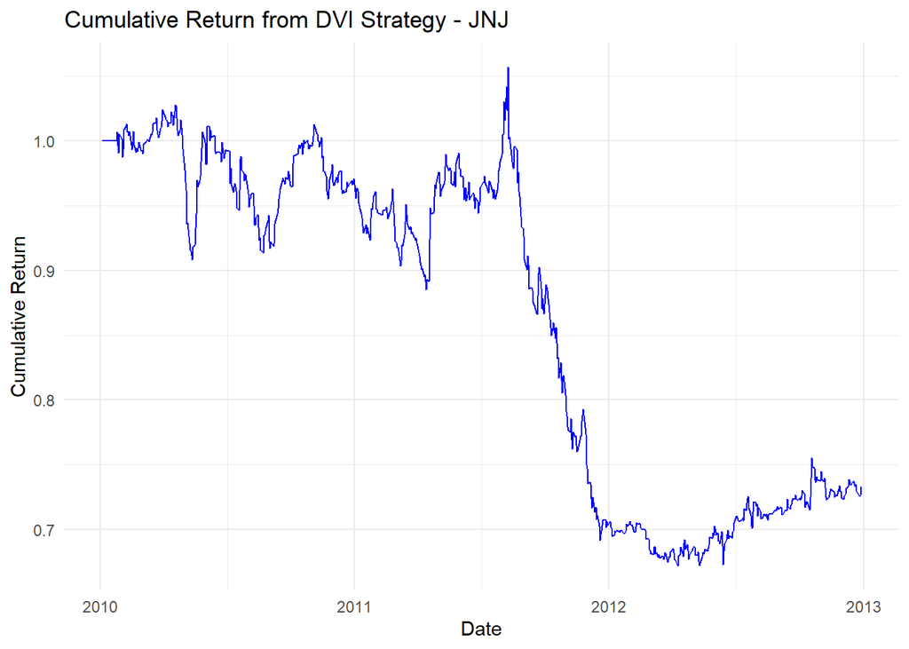

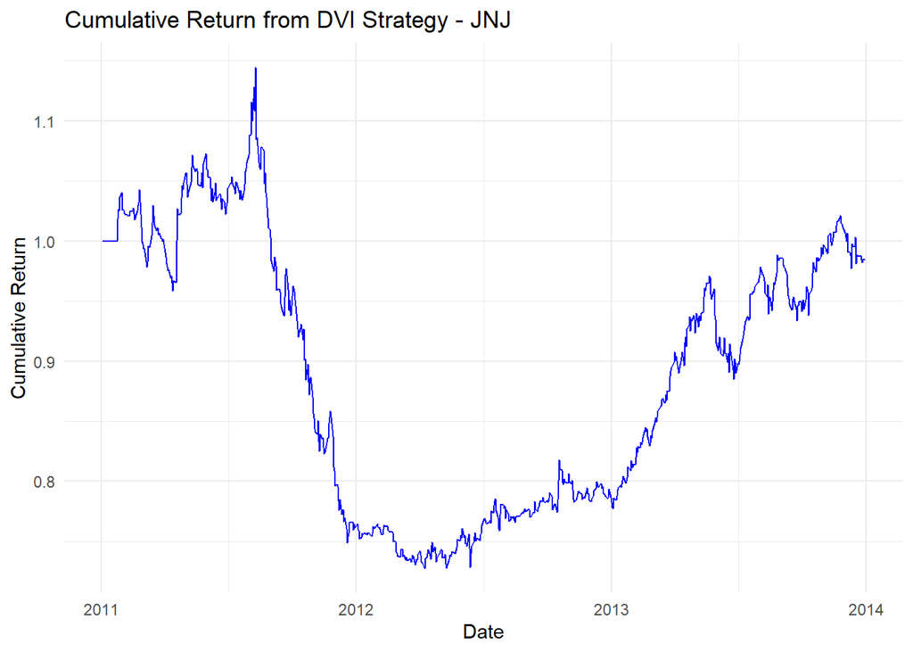

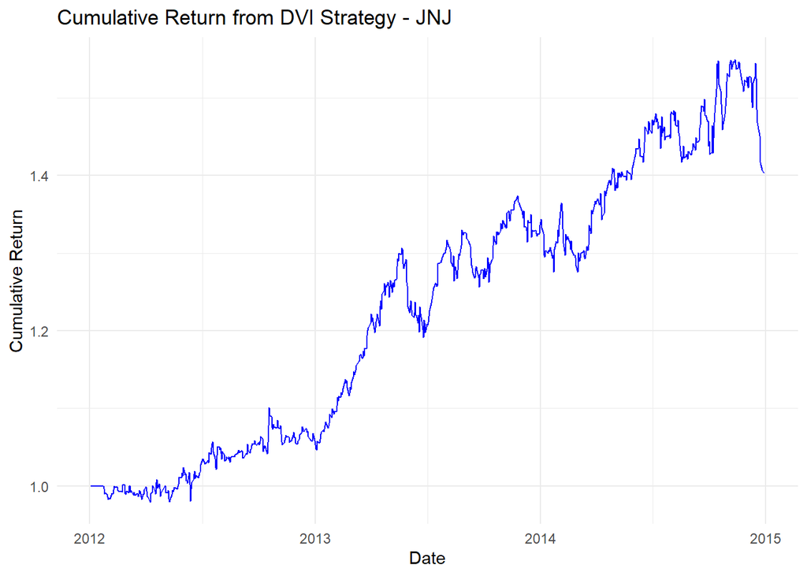

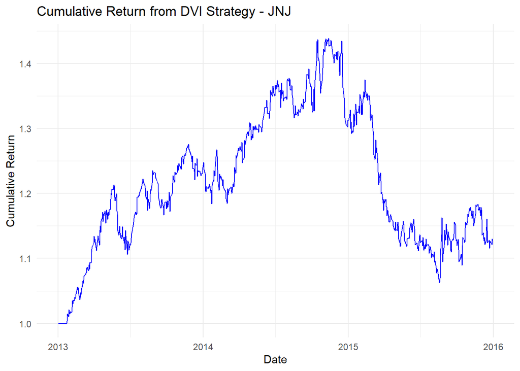

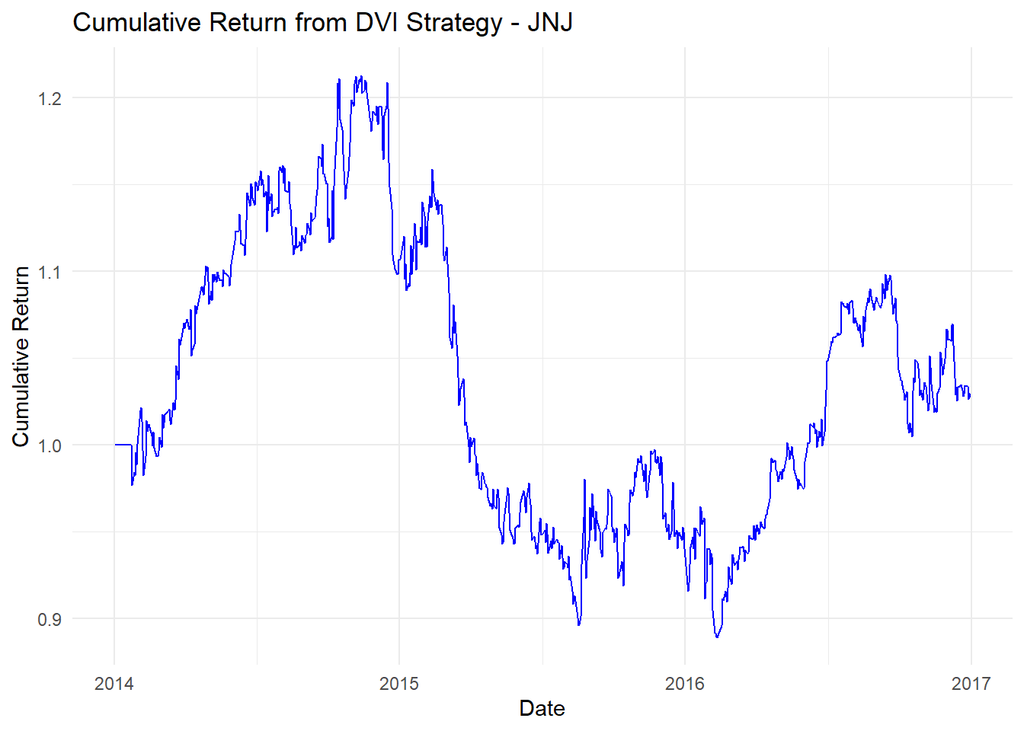

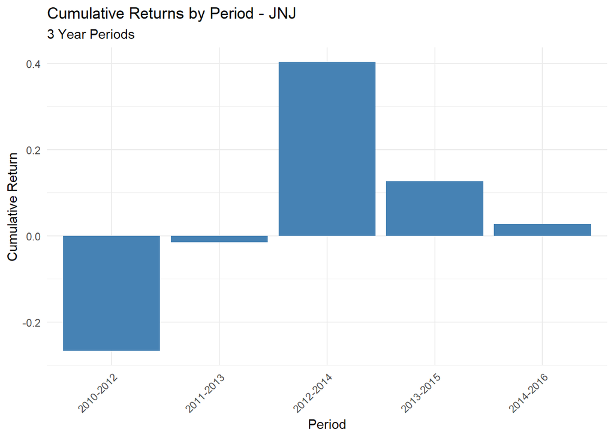

```r
# Function to simulate multiple backtest periods
simulate_multiple_backtests <- function(ticker, testing_period, date_range, dvi_threshold = 0.5) {
  # Extract start and end years from date_range
  start_year <- as.numeric(date_range[1])
  end_year <- as.numeric(date_range[2])
  # Create an empty list to store the results from each period
  all_results <- list()
  # Create a vector to store cumulative returns for plotting
  cumulative_returns <- data.frame(
    Period = character(),
    Cumulative_Return = numeric(),
    stringsAsFactors = FALSE
  )
  # Loop through each period in the range
  for (start in seq(start_year, end_year - testing_period + 1)) {
    end <- start + testing_period - 1
    # Create date strings for the period
    period_start <- paste0(start, "-01-01")
    period_end <- paste0(end, "-12-31")
    # Run backtest for this period
    period_result <- base_level_backtest(ticker, period_start, period_end, dvi_threshold)
    # Store the results in the list
    all_results[[paste0(start, "-", end)]] <- period_result
    # Store the cumulative return for this period
    cumulative_returns <- rbind(
      cumulative_returns,
      data.frame(
        Period = paste0(start, "-", end),
        Cumulative_Return = period_result$summary$Total_Return,
        stringsAsFactors = FALSE
      )
    )
  }
  # Create a data frame to store the summarized results
  summary_df <- data.frame(
    Period = character(),
    Total_Return = numeric(),
    Annualized_Sharpe = numeric(),
    Max_Drawdown = numeric(),
    stringsAsFactors = FALSE
  )
  # Populate summary data frame with results from each period
  for (period in names(all_results)) {
    result <- all_results[[period]]
    summary_df <- rbind(
      summary_df,
      data.frame(
        Period = period,
        Total_Return = result$summary$Total_Return,
        Annualized_Sharpe = result$summary$Annualized_Sharpe,
        Max_Drawdown = result$summary$Max_Drawdown,
        stringsAsFactors = FALSE
      )
    )
  }
  # Calculate the average of each metric over all periods
  summary_means <- colMeans(summary_df[, -1], na.rm = TRUE)
  summary_df <- rbind(
    summary_df,
    c("Average", summary_means)
  )
  # Create cumulative returns plot
  plot_cumulative_return <- ggplot(cumulative_returns, aes(x = Period, y = Cumulative_Return)) +
    geom_bar(stat = "identity", fill = "steelblue") +
    labs(
      title = paste("Cumulative Returns by Period -", ticker),
      subtitle = paste(testing_period, "Year Periods"),
      x = "Period",
      y = "Cumulative Return"
    ) +
    theme_minimal() +
    theme(axis.text.x = element_text(angle = 45, hjust = 1))
  # Print the plot
  print(plot_cumulative_return)
  # Return both summary statistics and plot data
  return(list(
    summary = summary_df,
    plot_data = cumulative_returns,
    all_results = all_results
  ))
}
simulation_results <- simulate_multiple_backtests("JNJ", 3, c("2010", "2016"), 0.5)
```

```r
print(simulation_results$summary)
```

```
##      Period        Total_Return  Annualized_Sharpe       Max_Drawdown
## 1 2010-2012  -0.267114017073488 -0.699653633531463  0.364342807262372
## 2 2011-2013 -0.0150457033534336 0.0302187594196374  0.364342807262372
## 3 2012-2014   0.402978700555715  0.971547095983291 0.0946616634182371
## 4 2013-2015   0.127198106057712  0.346031610541022  0.261399641444381
## 5 2014-2016  0.0272829230571145  0.134639364899307  0.267002764936843
## 6   Average  0.0550600018487239  0.156556639462359  0.270349936864841
```

## Function 3: Simulate Multiple DVI Thresholds

Now that we can calculate multiple time periods, we want to introduce a new step in which we can adjust our DVI thresholds. This function will now include all the prior values but now will let us input a low and high value for threshold, and increments to test in. By doing so, this allows us to determine how effective different thresholds may be.

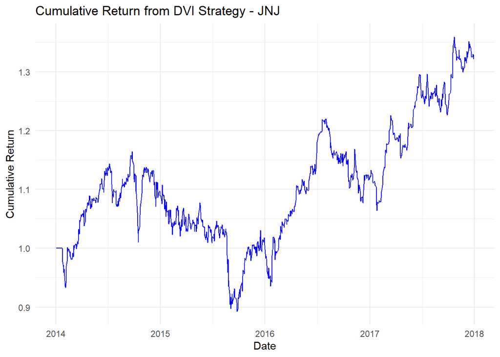

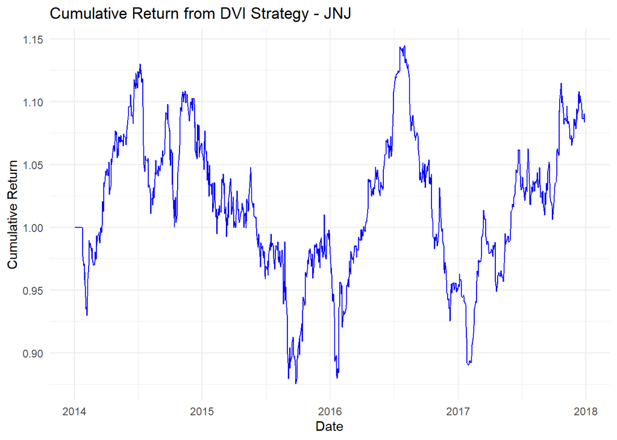

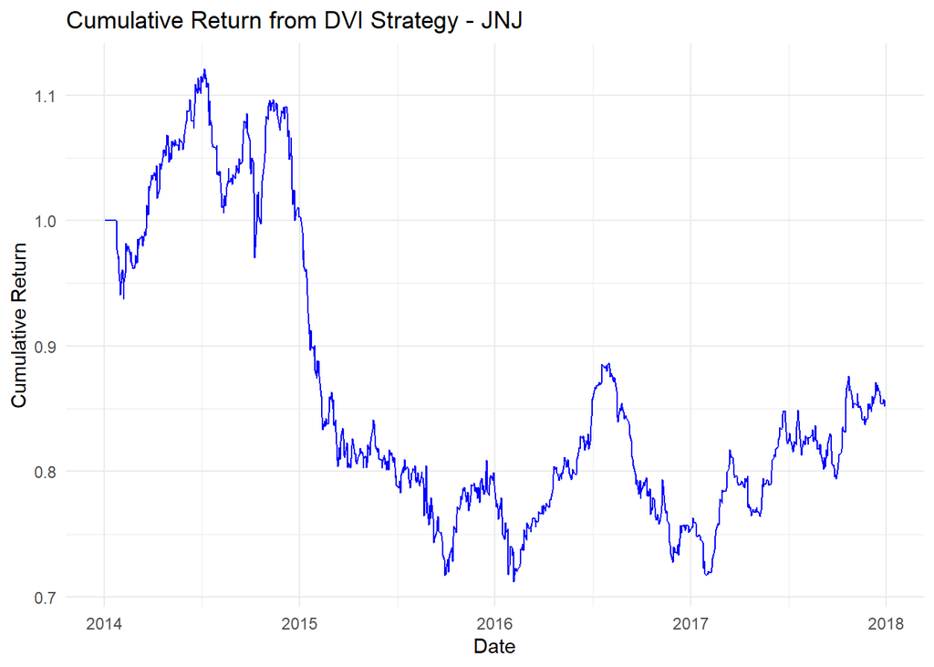

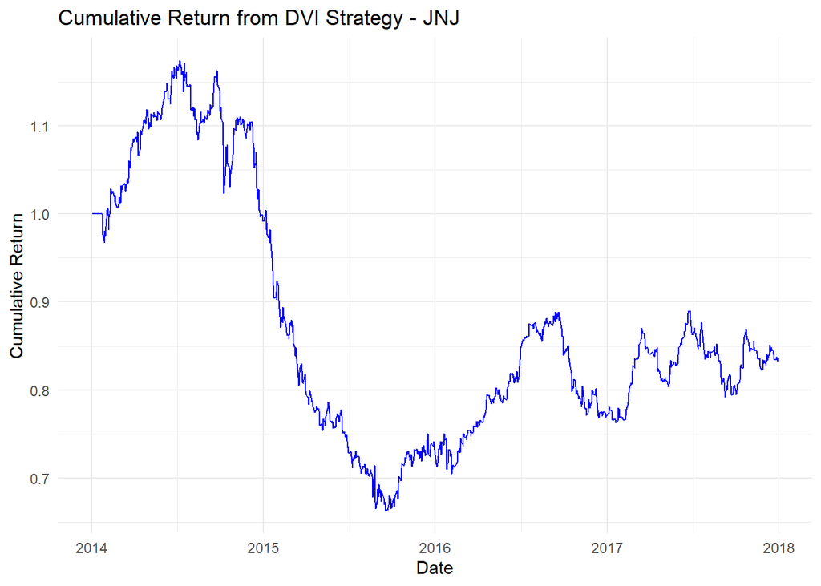

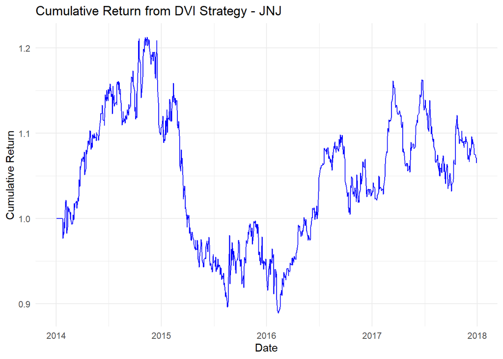

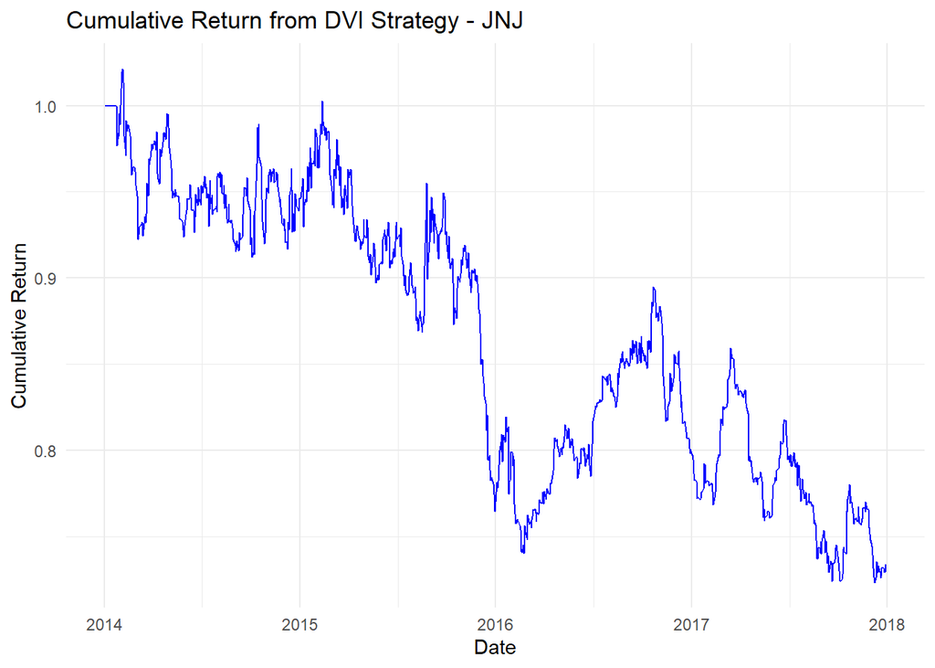

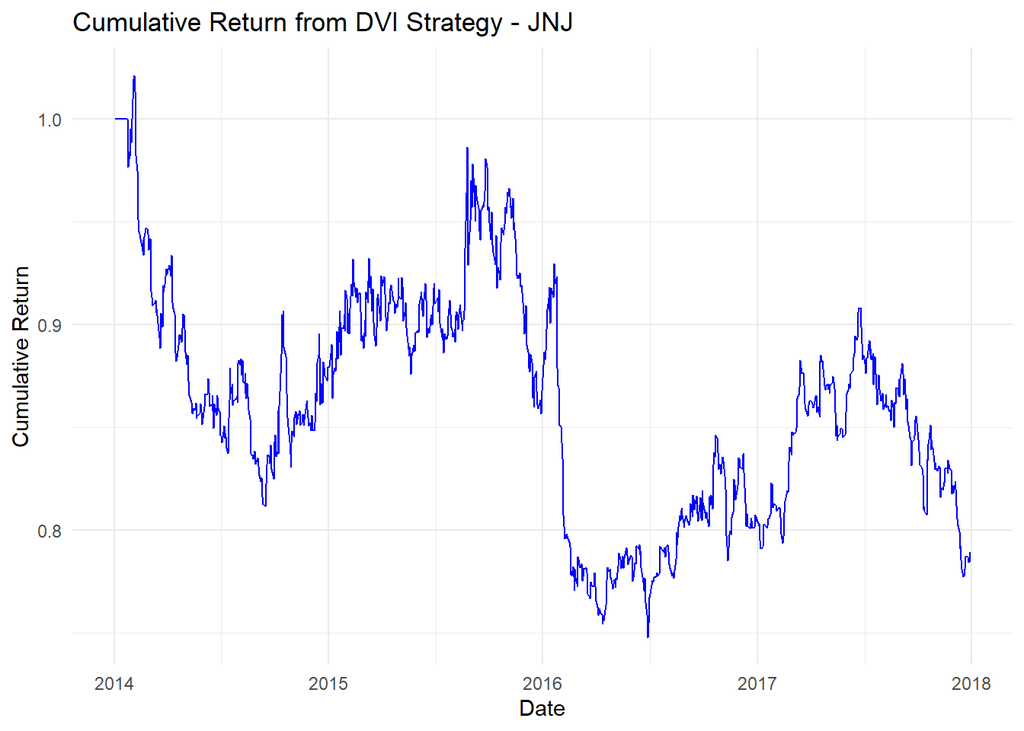

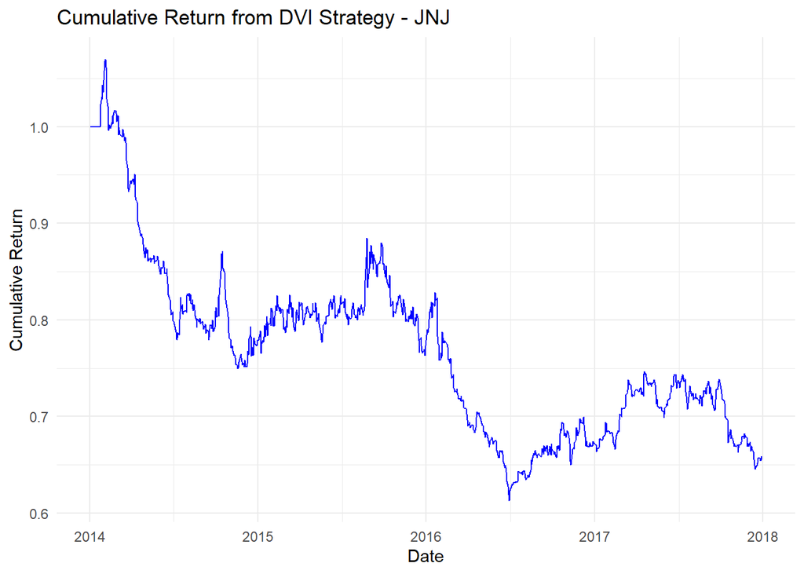

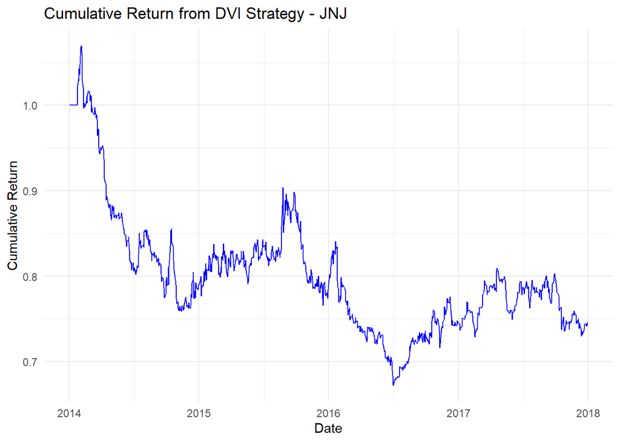

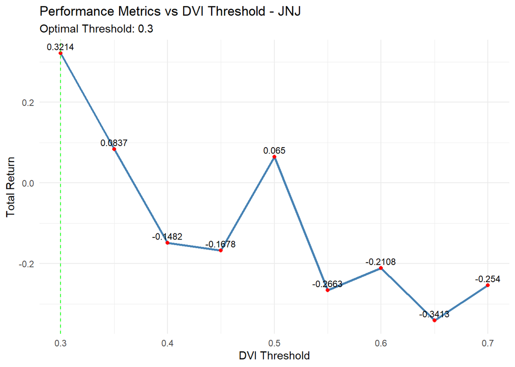

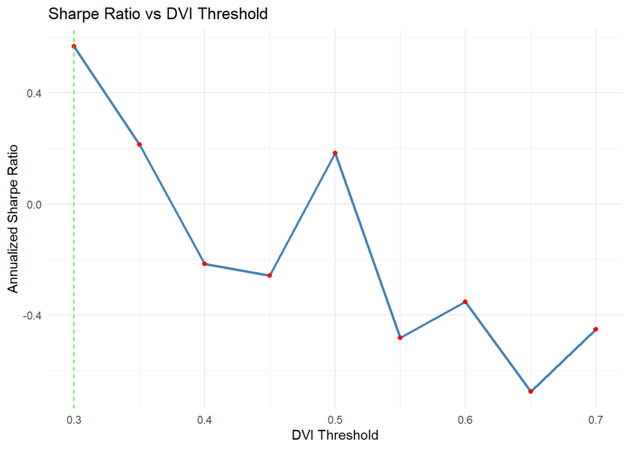

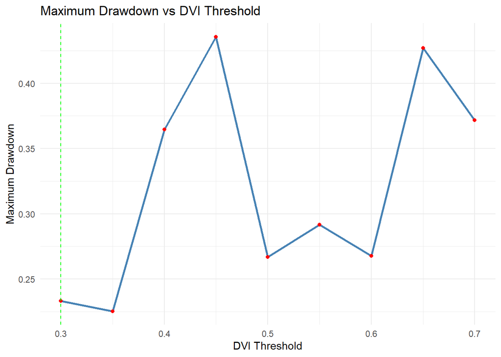

```r
# Function to simulate multiple DVI thresholds
simulate_multiple_dvi_thresholds <- function(ticker, start_date, end_date, low_threshold,
                                             high_threshold, increment = 0.01) {
  # Create a sequence of DVI thresholds
  dvi_thresholds <- seq(low_threshold, high_threshold, by = increment)
  # Create empty data frame to store results
  summary_df <- data.frame(
    DVI_Threshold = numeric(),
    Total_Return = numeric(),
    Annualized_Sharpe = numeric(),
    Max_Drawdown = numeric(),
    stringsAsFactors = FALSE
  )
  # Loop through each threshold
  for (threshold in dvi_thresholds) {
    # Run backtest with current threshold
    result <- base_level_backtest(ticker, start_date, end_date, threshold)
    # Add results to summary data frame
    summary_df <- rbind(
      summary_df,
      data.frame(
        DVI_Threshold = threshold,
        Total_Return = result$summary$Total_Return,
        Annualized_Sharpe = result$summary$Annualized_Sharpe,
        Max_Drawdown = result$summary$Max_Drawdown,
        stringsAsFactors = FALSE
      )
    )
  }
  # Find optimal threshold based on Total Return
  optimal_threshold <- summary_df$DVI_Threshold[which.max(summary_df$Total_Return)]
  # Create plots for each metric
  plot_return <- ggplot(summary_df, aes(x = DVI_Threshold, y = Total_Return)) +
    geom_line(color = "steelblue", size = 1) +
    geom_point(color = "red") +
    geom_vline(xintercept = optimal_threshold, linetype = "dashed", color = "green") +
    geom_text(aes(label = round(Total_Return, 4)),
              vjust = -0.5, color = "black", size = 3) +
    labs(
      title = paste("Performance Metrics vs DVI Threshold -", ticker),
      subtitle = paste("Optimal Threshold:", round(optimal_threshold, 3)),
      x = "DVI Threshold",
      y = "Total Return"
    ) +
    theme_minimal()
  plot_sharpe <- ggplot(summary_df, aes(x = DVI_Threshold, y = Annualized_Sharpe)) +
    geom_line(color = "steelblue", size = 1) +
    geom_point(color = "red") +
    geom_vline(xintercept = optimal_threshold, linetype = "dashed", color = "green") +
    labs(
      title = "Sharpe Ratio vs DVI Threshold",
      x = "DVI Threshold",
      y = "Annualized Sharpe Ratio"
    ) +
    theme_minimal()
  plot_drawdown <- ggplot(summary_df, aes(x = DVI_Threshold, y = Max_Drawdown)) +
    geom_line(color = "steelblue", size = 1) +
    geom_point(color = "red") +
    geom_vline(xintercept = optimal_threshold, linetype = "dashed", color = "green") +
    labs(
      title = "Maximum Drawdown vs DVI Threshold",
      x = "DVI Threshold",
      y = "Maximum Drawdown"
    ) +
    theme_minimal()
  # Arrange and print plots
  print(plot_return)
  print(plot_sharpe)
  print(plot_drawdown)
  # Return results
  return(list(
    summary = summary_df,
    optimal_threshold = optimal_threshold,
    plots = list(
      return_plot = plot_return,
      sharpe_plot = plot_sharpe,
      drawdown_plot = plot_drawdown
    )
  ))
}
results <- simulate_multiple_dvi_thresholds(
  ticker = "JNJ",
  start_date = "2014-01-01",
  end_date = "2017-12-31",
  low_threshold = 0.3,
  high_threshold = 0.7,
  increment = 0.05
)
```